# Grad Rates: Brief Analysis and Correlation Matrices

### Correlation Matrices

Graduation rates have the strongest negative correlation with households in poverty and those with single parents in the entire US.

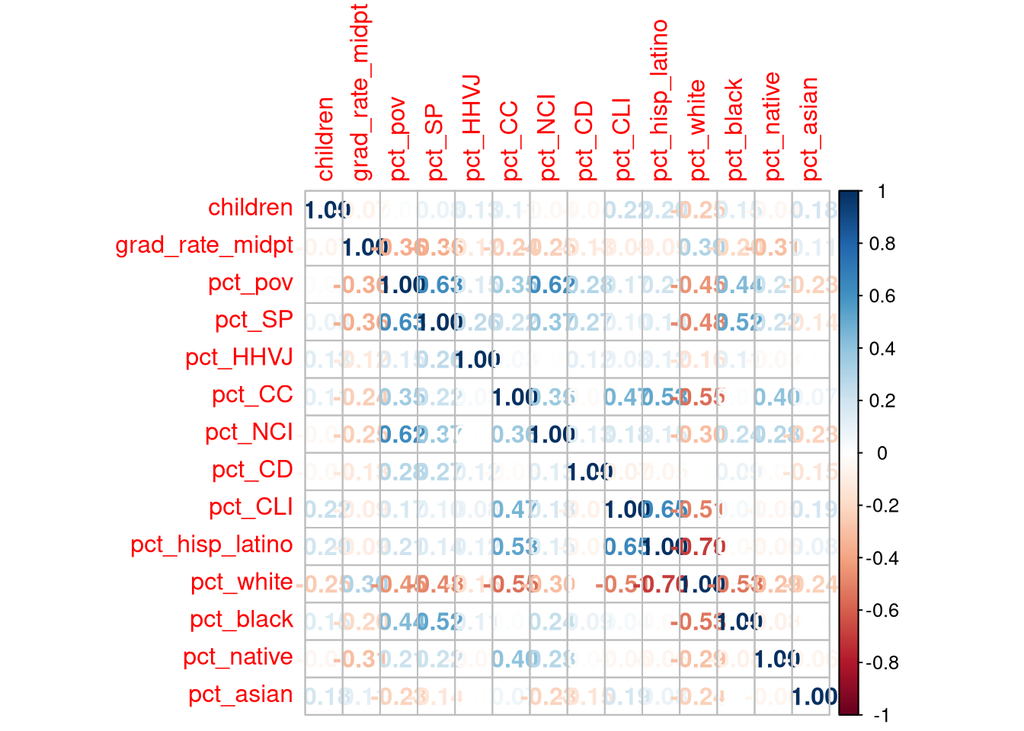

```r
grad_race_HH_corr <- grad_race_HH %>%
  select(dist,
         children,
         grad_rate_midpt,
         pct_pov:pct_CLI,
         pct_hisp_latino,
         pct_white,
         pct_black,
         pct_native,
         pct_asian)%>%
  na.omit()

grad_race_HH_corr[,2:ncol(grad_race_HH_corr)] %>%
    cor() %>%
    corrplot(method = "number")
```

I am curious how this matrix would change if I filtered out the outliers with grad rates specifically. It did not change it much, in fact it made the correlations between grad rates and the household conditions less significant.

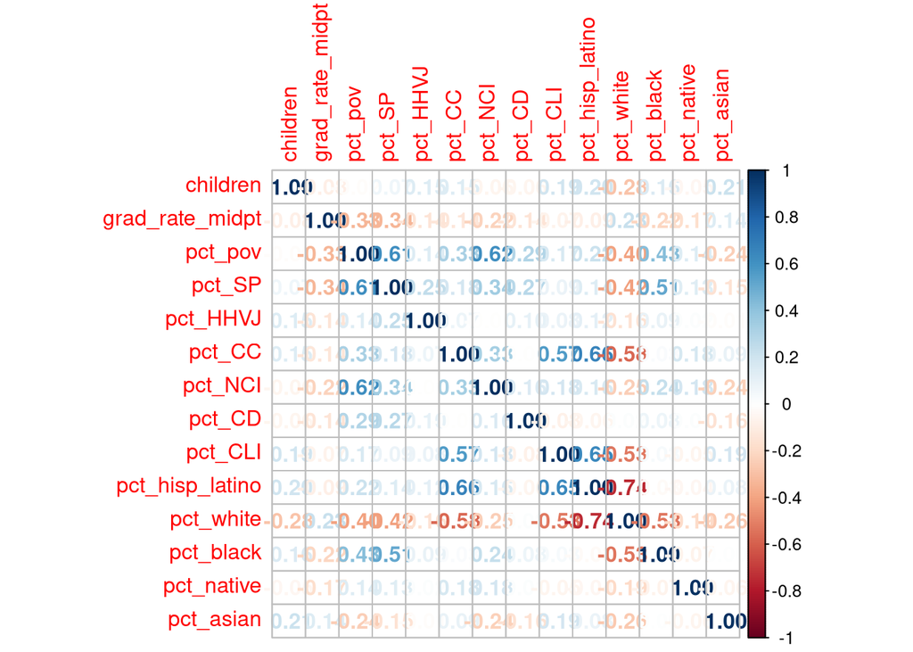

```r
grad_race_HH_norm <- grad_race_HH%>%
  filter(grad_rate_midpt > 75) %>%
  select(dist,
         children,
         grad_rate_midpt,
         pct_pov:pct_CLI,
         pct_hisp_latino,
         pct_white,
         pct_black,
         pct_native,
         pct_asian) %>%
  na.omit()

grad_race_HH_norm[,2:ncol(grad_race_HH_norm)] %>%
    cor() %>%
    corrplot(method = "number")
```

Lets look into some regional differences. Here is a correlation matrix of the Bible Belt states.

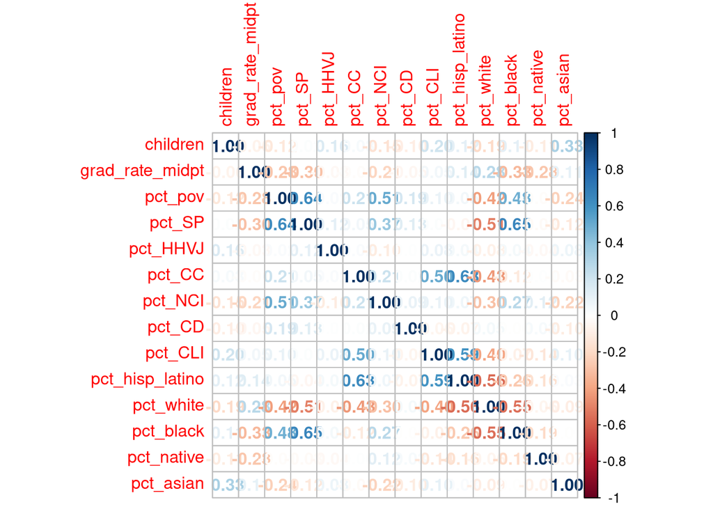

```r
bible_belt <- grad_race_HH %>%
  filter(state == "Alabama" |
         state == "Arkansas" |
         state == "Georgia"|
         state == "Kentucky"|
         state == "Louisiana"|
         state == "Mississippi"|
         state == "North Carolina"|
         state == "Oklahoma"|
         state == "South Carolina"|
         state == "Tennessee"|
         state == "Texas"|
         state == "Utah") %>%
  select(dist,
         children,
         grad_rate_midpt,
         pct_pov:pct_CLI,
         pct_hisp_latino,
         pct_white,
         pct_black,
         pct_native,
         pct_asian) %>%
  na.omit()

bible_belt[,2:ncol(bible_belt)] %>%
    cor() %>%
    corrplot(method = "number")
```

Now lets see about grad rates in states with the “worst” school systems. (https://www.newsnationnow.com/us-news/list-states-with-the-best-and-worst-public-school-systems/)

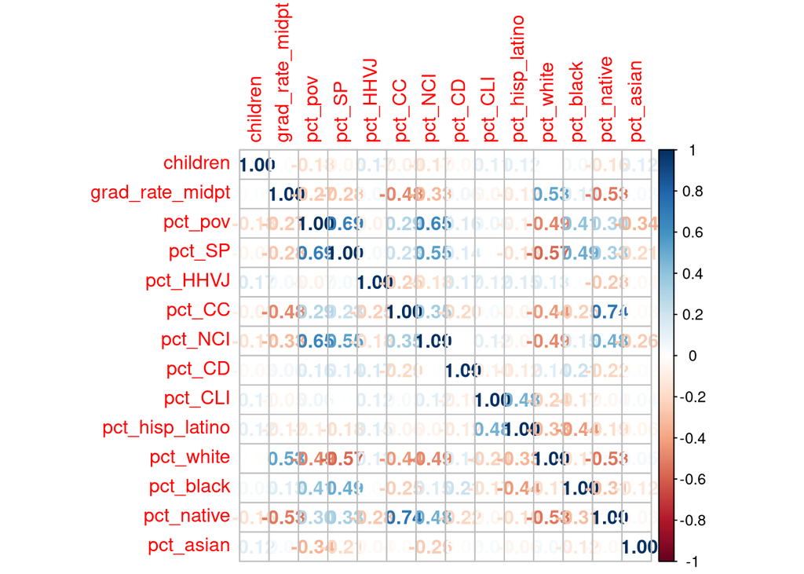

```r
worst_states <- grad_race_HH %>%
  filter(state == "Alabama" |
         state == "Alaska" |
         state == "Arizona"|
         state == "Louisiana"|
         state == "New Mexico") %>%
  select(dist,
         children,
         grad_rate_midpt,
         pct_pov:pct_CLI,
         pct_hisp_latino,
         pct_white,
         pct_black,
         pct_native,
         pct_asian) %>%
  na.omit()

worst_states[,2:ncol(worst_states)] %>%
    cor() %>%
    corrplot(method = "number")
```

What about the states with the “best” school systems? This plot is especially fascinating with a significantly higher negative correlation between grad rates and household conditions, as well as for black and Hispanic students.

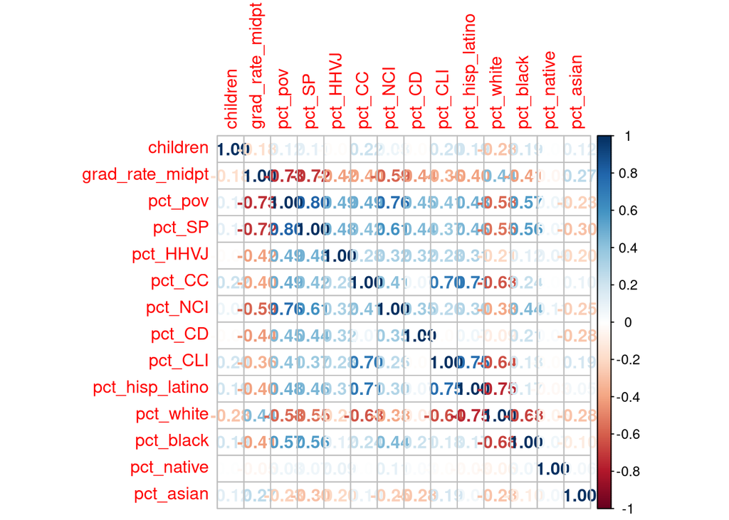

```r
best_states <- grad_race_HH %>%
  filter(state == "Massachusetts" |
         state == "Connecticut" |
         state == "New Jersey"|
         state == "Virginia"|
         state == "New Hampshire") %>%
  select(dist,
         children,
         grad_rate_midpt,
         pct_pov:pct_CLI,
         pct_hisp_latino,
         pct_white,
         pct_black,
         pct_native,
         pct_asian) %>%
  na.omit()

best_states[,2:ncol(best_states)] %>%
    cor() %>%
    corrplot(method = "number")
```

### Visualizations

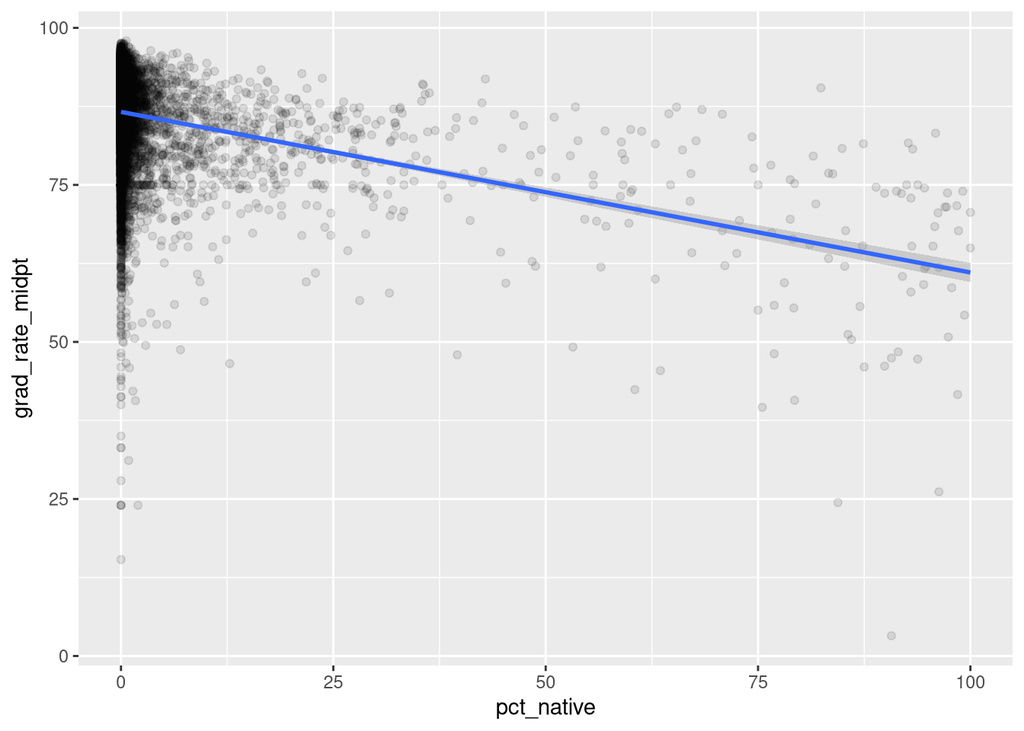

```r
ggplot(grad_race_HH,
       aes(x = pct_native, y = grad_rate_midpt)) +
    geom_point(alpha = 0.1) +
    geom_smooth(method = "lm", se = T)
```